# Estadística Social: Introducción a la inferencia

Daniel Quinteros (@dquinterosr). Traducido y adaptado de https://rawgit.com/jjmedinaariza/LAWS70821/master/Week_3_Foundations.html

18/9/2020

**ADVERTENCIA:** todos los datos que vamos a utilizar esta semana son simulados. Cualquier semejanza con la realidad es pura coincidencia.

## 1. Introducción

Ahora que ya conoces los conceptos de distribución y probabilidad, podemos aplicarlos para producir información que tenga validez estadística. Supongamos que una investigación busca conocer la extensión de situaciones de criminalidad en la región de Tarapacá. Una aproximación descriptiva, buscaría información en las estadísticas policiales o en los datos que pudiera entregar la Fiscalía, la Defensoría o el Poder Judicial. El problema es que podemos intuir que no todas las situaciones de violencia son denunciadas, lo que se conoce como la *cifra oculta*, es decir, aquellos delitos que nunca llegan a ser conocidos por las agencias estatales.

Frente a esta dificultad, podríamos considerar la opción de obtener dicha información directamente desde las personas y preguntarles si han sufrido alguna de las situaciones que nuestro marco teórico y/o jurídico describe como violentas. Sin embargo, sería muy costoso llevar a cabo un CENSO, por lo cual se toma una muestra de personas para consultarles si han experimentado alguna de las situaciones de interés. El problema acá es saber cómo es posible estar seguros que el resultado de la muestra refleja adecuadamente la realidad de toda la población, lo cual se conoce como **error de muestreo**, es decir, la diferencia entre el valor real (desconocido) y el que obtenemos de nuestra muestra (conocido).

Para entender mejor esta idea, vamos a simular datos para toda la población de Tarapacá (330.558), asumiendo que esta es la distribución de la cantidad de veces que una persona fue víctima de algún delito:

```r
set.seed(100)
crimen <- rnbinom(330558, mu = 0.5, size = 0.3)
mean(crimen)
```

```
## [1] 0.4979217
```

```r
sd(crimen)
```

```
## [1] 1.152972
```

Ahora que ya conoces los estadísticos descriptivos de la variable **crimen**, miremos su distribución:

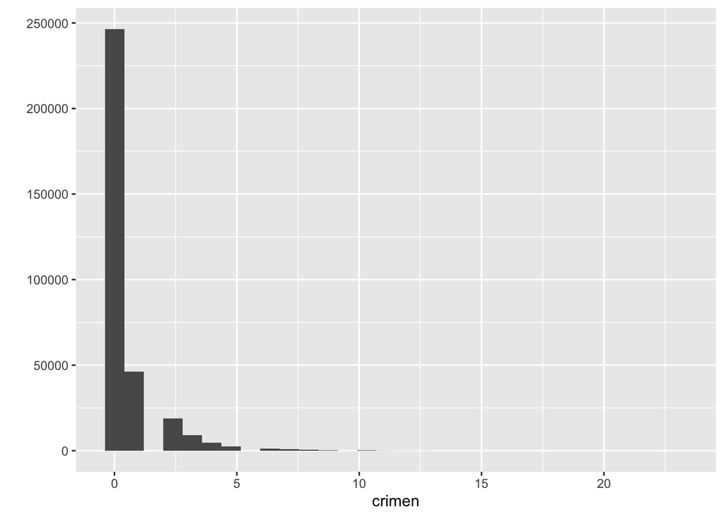

```r
library(ggplot2)
qplot(crimen)
```

Como verás, la mayor cantidad de personas en este ejemplo no han sido víctimas de delitos (crimen=0). Para saber cuántos si fueron víctimas, podemos sumar la cantidad de casos que tienen valor mayor que cero (crimen>0).

```r
sum(crimen>0)
```

```
## [1] 84058
```

Pongamos este resultado en una tabla, para crear una variable dicotómica y saber quienes fueron o no víctima de delitos.

```r
tarapaca <- data.frame(delitos=crimen)
tarapaca$victima <- ifelse(tarapaca$delitos>0,c("Si"),c("No")) #ifelse(condicion, verdadero, falso)
table(tarapaca$victima)
```

```
##
##     No     Si
## 246500  84058
```

Ahora, siguiendo buena parte de la literatura criminológica, podemos imaginar que las personas que han sido victimizadas son justamente quienes tienen menores ingresos. Por eso, podemos crear una variable aleatoria para cada grupo, utilizando la media de ingresos que hemos visto anteriormente, para los cuartiles 2 y 4. La desviación estándar la mantendremos constante para no alterar la forma de la curva, sino sólo su posición (por favor, no olvides que hasta acá todo es ficción, son datos simulados).

```r
tarapaca$ingresos[tarapaca$victima == "No"] <- rnorm(246322, mean=415613, sd=50000) #Q4
tarapaca$ingresos[tarapaca$victima == "Si"] <- rnorm(84236, mean=169990, sd=50000) #Q2
mean(tarapaca$ingresos)
```

```
## [1] 353163.5
```

Ahora vamos a utilizar el paquete *plyr()* para obtener la media de ingresos para cada grupo por separado. Para facilitar el gráfico que sigue más adelante, podemos guardar los resultados en un objeto que llamaremos *ingresos*, utilizando la función *ddply()*.

```r
library(plyr)
ingresos <- ddply(tarapaca, "victima", summarise, ingresos = mean(ingresos))
ingresos
```

```
##   victima ingresos
## 1      No 415676.3
## 2      Si 169844.7
```

Como puedes ver, el objeto *ingresos* contiene la media simulada de ingresos para cada grupo. Utilizando *ggplot()*, podemos graficar ambas distribuciones.

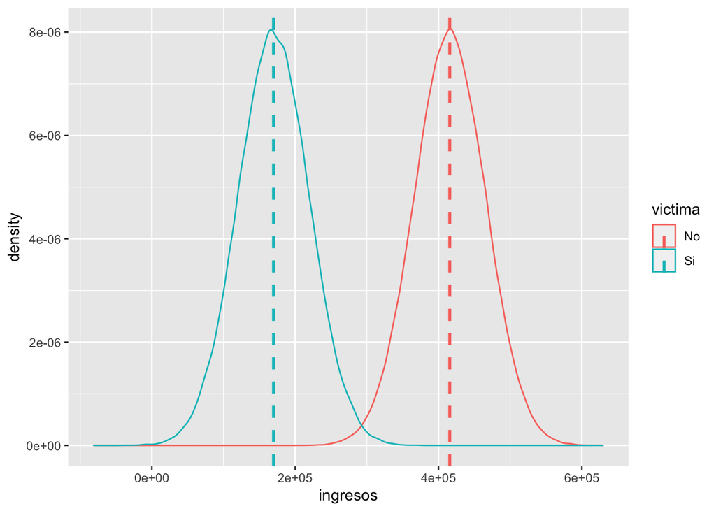

```r
ggplot(tarapaca, aes(x = ingresos, colour = victima)) +
  geom_density() +
  geom_vline(aes(xintercept = ingresos, colour = victima), data = ingresos,
             linetype = "dashed", size = 1)
```

Hasta acá, como los datos los hemos simulados, sabemos como se comporta la población. Pero en la vida real, generalmente no contamos con esa información. Y si no existe, ¡podemos producirla!

## 2. Muestreo

Como veremos, generar muestras aleatorias en R es bastante fácil. Podemos utilizar la función *sample()* del paquete *mosaic()*. A continuación, se muestra como extraer una muestra de los ingresos de 10 casos, a partir de los datos que hemos simulado previamente:

```r
library(mosaic)
sample(tarapaca$ingresos, 10)
```

```
##  [1] 192144.1 337029.9 375465.1 296225.6 425136.6 408009.0 104162.2 476348.8
##  [9] 396615.3 354275.2
```

```r
mean(sample(tarapaca$ingresos, 10))
```

```
## [1] 320198
```

Cada vez que se repite el cálculo, se genera un valor diferente. Este es justamente el problema de las muestras: los valores entre las muestras nunca son iguales. Puedes comprobarlo si extraemos sucesivas muestras del mismo tamaño.

```r
do(15) * with(sample(tarapaca, 10),mean(ingresos))
```

```
##        with
## 1  322007.0
## 2  410423.6
## 3  361214.9
## 4  342304.5
## 5  357366.2
## 6  388886.0
## 7  347306.0
## 8  384855.5
## 9  330970.9
## 10 357603.6
## 11 344861.6
## 12 355820.4
## 13 338661.0
## 14 348414.8
## 15 365202.3
```

Podemos guardar los resultados de este ejercicio en un objeto, para después graficarlo. El código a continuación permite generar un *data.frame* con los resultados de las medias de 15 muestras aleatorias.

```r
sample_ingresos <- do(15) * with(sample(tarapaca, 10),mean(ingresos))
names(sample_ingresos) #ver nombres de variables del objeto
```

```
## [1] "with"
```

Antes de pasar al gráfico, vamos a crear un objeto con la media poblacional (que verás después en rojo)

```r
ingresos_mean <- data.frame(mean(tarapaca$ingresos))
#ver nombres de variables del objeto
names(ingresos_mean)
```

```
## [1] "mean.tarapaca.ingresos."
```

Ahora si podemos pasar al gráfico, utilizando la función *ggplot()*

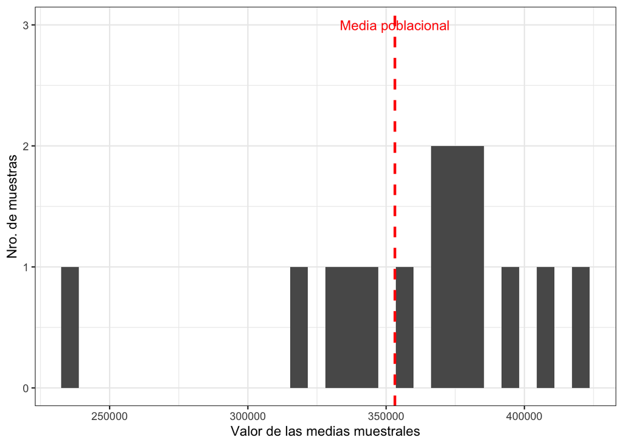

```r
#And we can plot it then
ggplot(sample_ingresos, aes(x = with)) +
  geom_histogram() +
  geom_vline(aes(xintercept = mean.tarapaca.ingresos.), data = ingresos_mean,
             linetype = "dashed", size = 1, colour = "red") +
  labs(x = "Valor de las medias muestrales", y = "Nro. de muestras") +
  annotate("text", x = 353163, y = 3, label = "Media poblacional", colour = "red") + #Annotate se utiliza para insertar otros elementos dentro del gráfico.
  theme_bw()
```

Como no hemos utilizado *set.seed()*, tus resultados pueden ser algo diferentes de lo que se ha presentado hasta acá, pero ya te habrás dado cuenta del gran problema de las muestras: no siempre se acercan a la realidad.

### 3. Distribuciones muestrales

Un concepto clave en esta parte del curso, es el de **distribución muestral**: la descripción de la probabilidad de obtener cada uno de los resultados posibles. Como ejemplo, vamos a generar 50.000 muestras de 10 casos, para luego calcular sus medias, lo cual puede demorar unos cuantos minutos…

```r
sampledist_ingresos_10 <- do(50000) * with(sample(tarapaca, 10), mean(ingresos))
```

… ¡uf, al fin! Ahora vamos a calcular la media de la distribución muestral de las medias…

```r
mean(sampledist_ingresos_10$with) #media de las medias muestrales
```

```
## [1] 352999.8
```

… para compararla con la media poblacional:

```r
mean(tarapaca$ingresos) #media poblacional
```

```
## [1] 353163.5
```

Como verás, la diferencia entre la media que acabamos de producir con 50.000 muestras de 10 casos cada una **!es bastante similar a la media real de la población!**

[figure not shown]

> Lo que podemos observar es lo que se conoce como el **teorema central del límite**, gracias al cual sabemos que: 1. La media de las distribución muestral de las medias (valores esperados) es igual a la media de la población. 2. Las aproximaciones se hacen exactas cuando *n* tiende a infinito.

Puedes probar tomando un millón de muestras, pero te puede tomar unos cuantos días. Mejor confiemos en el [!teorema central del límite (o teorema del límite central)!](http://funes.uniandes.edu.co/1204/1/Inzunsa2008Comprension_SEIEM_349.pdf)

Para entender mejor esta idea, echemos un vistazo a la distribución muestral de las medias:

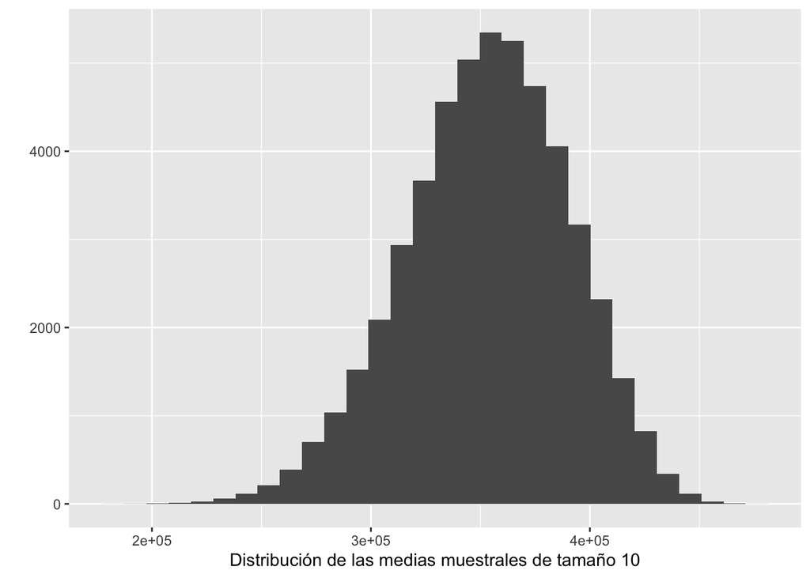

```r
qplot(sampledist_ingresos_10$with, xlab = "Distribución de las medias muestrales de tamaño 10")
```

Como verás, la distribución muestral de las medias de variables que se encuentran normalmente distribuidas en la población, también tendrá una distribución normal. En simple, lo que nos está diciendo esta distribución muestral es que la mayoría de las medias que podamos generar a partir de muestras aleatorias, se encuentran agrupadas en torno a la media real de la población.

Aunque no conozcamos su valor real (parámetro), podemos **inferirlo** a partir de las muestras aleatorias que podamos generar. Claro, tendremos algunas muestras que estarán *muy arriba* o *muy abajo* del valor a nivel poblacional (parámetro), pero la verdad es que la mayoría de las muestras estará cerca del valor paramétrico.

> En suma, lo que podemos concluir hasta acá, es que las medias que podamos obtener a partir de muestras aleatorias se comportan de una manera predecible. Cuando obtengamos una muestra de X cantidad de casos, no podremos conocer el valor real de la población (parámetro), pero sí sabremos que la probabilidad de obtener un valor extremo, muy alejado de la media poblacional, es menor que obtener un valor cercano al parámetro. ADVERTENCIA: no olvides que estamos asumiendo que la variable se encuentra normalmente distribuida en la población (los ingresos, por ejemplo, no tienen una distribución normal en la vida real).

[figure not shown]

Pero hay más, no dependemos exclusivamente del azar. **¿Has pensado qué pasaría si aumentamos el tamaño de la muestra?**

Para eso vamos a repetir el ejercicio anterior, tomando sucesivas muestras de 30, 100 y 1000 casos

```r
sampledist_ingresos_30 <- do(50000) * with(sample(tarapaca, 30), mean(ingresos))
sampledist_ingresos_100 <- do(50000) * with(sample(tarapaca, 100), mean(ingresos))
sampledist_ingresos_1000 <- do(50000) * with(sample(tarapaca, 1000), mean(ingresos))
```

Ahora vamos a graficar esas distribuciones:

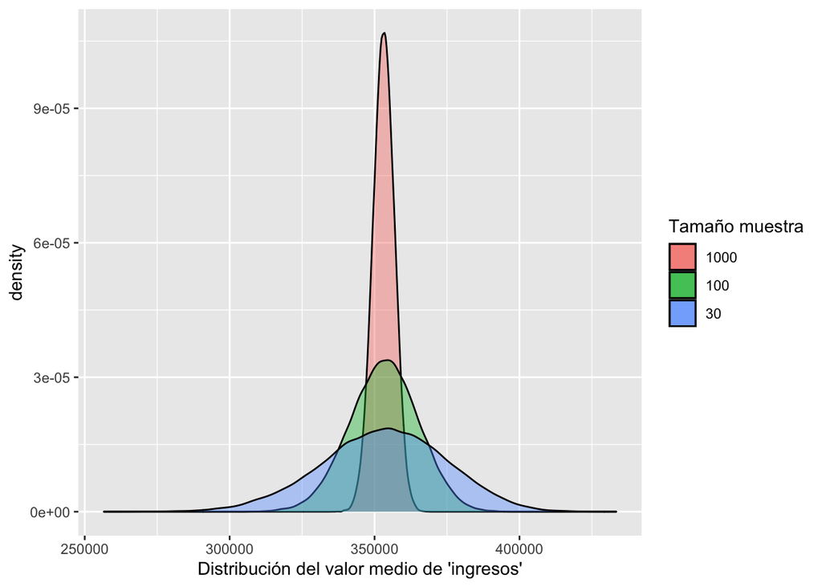

```r
ggplot() +
    geom_density(data = sampledist_ingresos_1000, aes(x = with, fill = "1000"), position = "identity", alpha = 0.4) +
   geom_density(data = sampledist_ingresos_100, aes(x = with, fill = "100"), position = "identity", alpha = 0.4) +
   geom_density(data = sampledist_ingresos_30, aes(x = with, fill = "30"), position = "identity", alpha = 0.4) +
  labs(fill = "Tamaño muestra") + #Cambiamos el título de la leyenda
  scale_fill_discrete(limits = c("1000", "100", "30")) + #Ordena los items en la leyenda
  xlab("Distribución del valor medio de 'ingresos'")
```

¿Qué puedes observar? ¿Cuál es el efecto del tamaño de la muestra sobre la distribución muestral?

> Ley de los grandes números: a medida que el tamaño de la muestra aumenta, un mayor número de muestras tiende a centrarse alrededor de la media de la distribución muestral. Como dice Ferris, entre mayor sea el tamaño de la muestra, menor será el error estándar (la desviación estándar de una distribución muestral).

Veamos los estadísticos descriptivos de cada una, utilizando la función *favstats()* del paquete *mosaic*:

```r
favstats(~with, data = sampledist_ingresos_30)
```

```
##       min       Q1   median       Q3    max     mean       sd     n missing
##  256641.4 338834.7 353589.7 367877.4 433345 353018.8 21537.14 50000       0
```

```r
favstats(~with, data = sampledist_ingresos_100)
```

```
##       min       Q1 median       Q3      max     mean       sd     n missing
##  301143.5 345302.4 353381 361204.6 399114.7 353194.3 11790.98 50000       0
```

```r
favstats(~with, data = sampledist_ingresos_1000)
```

```
##       min       Q1   median       Q3    max     mean       sd     n missing
##  335486.5 350641.5 353153.4 355638.8 368617 353122.9 3712.802 50000       0
```

Como puedes ver, la media de las distribuciones muestrales es bastante similar en todos los casos, independiente del tamaño de las muestras (cualquier leve diferencia se debe básicamente a que sólo extrajimos 50000 muestras). Sin embargo, el rango de valores posibles es mucho menor en muestras grandes que en muestras pequeñas. Cuando las muestras son pequeñas, aumenta la probabilidad de encontrar valores más alejados de la media poblacional.

Esta variabilidad es conocida como el **error estándar**: la desviación estándar de una distribución muestral.

Pero ¿qué pasa con las variables que no se encuentran normalmente distribuidas? ¿Qué podemos hacer, por ejemplo, con la variable *delitos*?

```r
sampledist_delitos_30 <- do(50000) * with(sample(tarapaca, 30), mean(delitos))
sampledist_delitos_100 <- do(50000) * with(sample(tarapaca, 100), mean(delitos))
sampledist_delitos_1000 <- do(50000) * with(sample(tarapaca, 1000), mean(delitos))
```

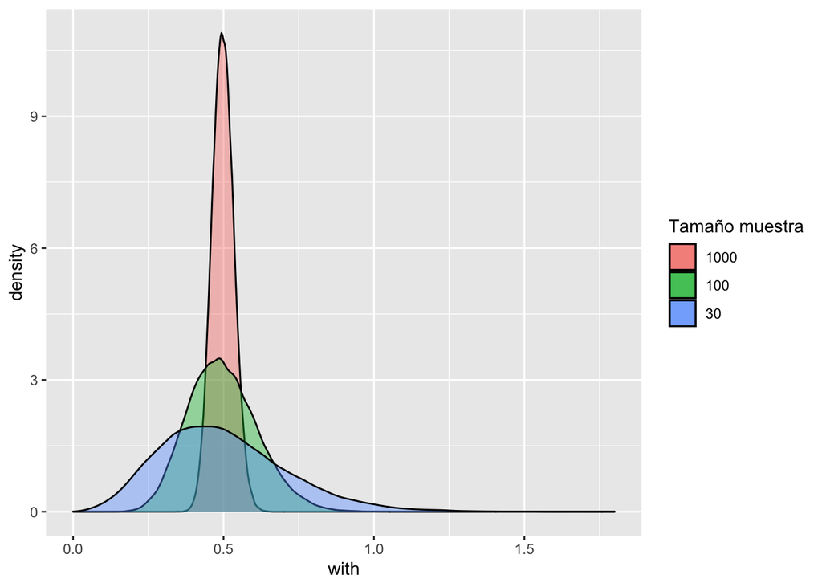

```r
ggplot() +
    geom_density(data=sampledist_delitos_1000, aes(x = with, fill = "1000"), position = "identity", alpha = 0.4) +
   geom_density(data=sampledist_delitos_100, aes(x = with, fill = "100"), position = "identity", alpha = 0.4) +
   geom_density(data=sampledist_delitos_30, aes(x = with, fill = "30"), position = "identity", alpha = 0.4) +
  labs(fill = "Tamaño muestra") + #Cambiamos el título de la leyenda
  scale_fill_discrete(limits = c("1000", "100", "30")) #Ordena los items en la leyenda
```

```r
favstats(~with, data = sampledist_delitos_30)
```

```
##  min        Q1    median        Q3 max     mean        sd     n missing
##    0 0.3333333 0.4666667 0.6333333 1.8 0.498868 0.2120879 50000       0
```

```r
favstats(~with, data = sampledist_delitos_100)
```

```
##   min   Q1 median   Q3  max     mean        sd     n missing
##  0.11 0.42   0.49 0.57 1.09 0.497809 0.1153228 50000       0
```

```r
favstats(~with, data = sampledist_delitos_1000)
```

```
##    min    Q1 median    Q3   max      mean         sd     n missing
##  0.347 0.473  0.497 0.522 0.655 0.4978318 0.03624535 50000       0
```

```r
mean(tarapaca$delitos)
```

```
## [1] 0.4979217
```

Puedes ver que ocurre algo similar. A pesar de que la variable delitos no se distribuya normalmente, la distribución muestral de las medias de la variable *delitos* se vuelve cada vez más normal, a medida que aumenta la muestra.

Interesante, pero ¿para qué sirve todo esto? Bueno, nos indica que si queremos tener buenos estimadores de los parámetros, debiéramos sumar más casos a la muestra. Además, si bien sabemos que la muestra puede estar errada, ahora podemos predecir qué tan errada podría estar.

Si aún tienes dudas, puedes ver este buen video explicativo de [Khan Academy](https://youtu.be/k5EbijWu-Ss) (*en inglés, pero con subtítulos disponibles en español*)

## 4. Intervalos de confianza

La media muestral puede ser el mejor estimador de la media poblacional (por eso se dice que la media muestral es el estimador insesgado de la media paramétrica), la cual se hace cada vez más precisa a medida que aumenta el tamaño de la muestra. Pero como hemos visto, también es altamente probable que cada valor muestral contenga una diferencia con el valor poblacional, lo que conocemos como **error muestral**. ¿Cómo podemos entonces considerar estos elementos para controlar la inherente incertidumbre de cada muestra?

Como ya conoces el **teorema del límite central** y la **ley de los grandes números**, sabrás que la clave está justamente en que la distribución muestral se *aproxima* a la normalidad, particularmente con muestras grandes. Este *supuesto* nos permite aprovechar todo el conocimiento que ya tenemos acerca de las propiedades de una curva de **distribución normal** como, por ejemplo, que ya sabemos la proporción de casos que caen entre los distintos valores estandarizados (puntajes Z):

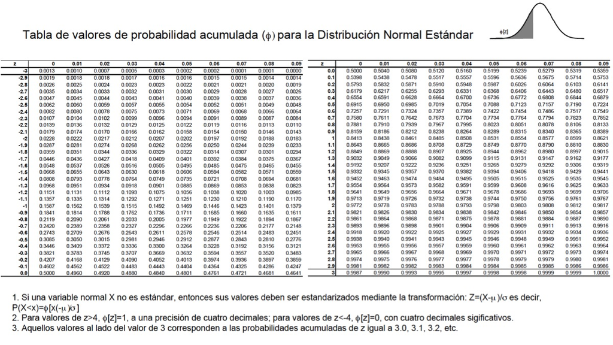

Sólo a modo de recordatorio, fíjate por ejemplo en que la media divide la distribución en dos partes iguales de 50% cada una; o que entre 0 (0,500) y 1 (0,8413) se encuentra el 34,13% de los casos (o de las muestras si nos referimos a una distribución muestral). ¿Quieres ejercitar un poco? Busca la proporción de área bajo la curva que se encuentra entre 0 y -1,96 (mitad izquierda de la tabla). Ahora multiplica esa proporción por dos.

¿Cuál es el resultado?

Z(-1,96) = 0,0250 0,0250 x 2 = 0,05

Si además recordamos que el total de la distribución es igual a 1, podemos tomar este valor y restarlo:

1 - 0,05 = 0,95

Es decir que, entre -1,96 y +1,96, se encuentra el 95% de los casos. Si lo llevamos a una distribución muestral sobre la cual podamos aceptar el supuesto de normalidad, podemos pronosticar que un **estadístico** de la muestra se encontrará cerca del **parámetro** de la población, en un 95% de las veces.

Todas estas ideas nos permiten confiar en que, aunque estemos trabajando con muestras y no con poblaciones, podemos construirnos una idea de qué tan distante se *podría* encontrar del valor real (parámetro). Para ello necesitamos establecer el **margen de error**, es decir, la máxima probabilidad de fallo que estamos dispuestos a asumir en nuestras estimaciones usando **muestras aleatorias**. En ciencias sociales existe cierto consenso en establecer este valor en 95%, de modo que exista una probabilidad que de cada 100 muestras, en 95 de ellas el **error muestral** sea inferior al **márgen de error**. A su vez, esto implica que sólo estamos dispuestos a tolerar un fallo en tan sólo 5% de las muestras, lo cual es una probabilidad bastante baja. Piénsalo un segundo: si supieras que en un saco hay sólo 5 pelotas rojas y 95 pelotas verdes y el profesor de estadística te diera la posibilidad de aprobar el curso (¡con un 7!), pero sólo si *por azar* sacas una pelota de color verde ¿aceptarías el reto?

Veamos un ejemplo con la variable *ingresos*:

```r
favstats(~with, data = sampledist_ingresos_100)
```

```
##       min       Q1 median       Q3      max     mean       sd     n missing
##  301143.5 345302.4 353381 361204.6 399114.7 353194.3 11790.98 50000       0
```

```r
sd(sampledist_ingresos_100$with)*1.96
```

```
## [1] 23110.33
```

Si el **error estándar** (desviación estándar de una distribución muestral) es igual a **$11.790,98**, podemos multiplicar ese valor por 1,96 y saber que *en el 95% de las muestras*, el estadístico tendrá una diferencia máxima de **$23.110,33**. ¿Y si aumentamos el tamaño de la muestra a 1000 casos? Mira cuánto ganarías en precisión:

```r
favstats(~with, data = sampledist_ingresos_1000)
```

```
##       min       Q1   median       Q3    max     mean       sd     n missing
##  335486.5 350641.5 353153.4 355638.8 368617 353122.9 3712.802 50000       0
```

```r
sd(sampledist_ingresos_1000$with)*1.96
```

```
## [1] 7277.091
```

A partir de esta información, podemos empezar a sincerar nuestras estimaciones y, en lugar de señalar que la media de ingresos es igual a **$353.163,5**, podemos decir que en realidad no lo sabemos, pero tenemos una confianza del 95% que la media se encontrará entre (*$353.163,5* - 1,96 x *error estándar*) y (*$353.163,5* + 1,96 x *error estándar**). Veamos un ejemplo con una muestra de 100 casos:

```r
set.seed(100) #para obtener siempre los mismos resultados
muestra1 <- sample(tarapaca, 100)
mean(muestra1$ingresos)
```

```
## [1] 359973.2
```

Recuerda que el **error estándar** de la distribución muestral con 100 casos, era igual a **$11.790,98** y que, multiplicado por 1,96, era igual a **$23.110,33**. Esta información nos permite determinar el **Límite de confianza inferior** y el **Límite de confianza superior**, sumando y restando esta cifra al valor de la media. En este caso, entre **$336,862.9** y **$383,083,6**:

```r
mean(muestra1$ingresos) - sd(sampledist_ingresos_100$with) * 1.96
```

```
## [1] 336862.9
```

```r
mean(muestra1$ingresos) + sd(sampledist_ingresos_100$with) * 1.96
```

```
## [1] 383083.6
```

Veamos un ejemplo directamente utilizando R. Desde las 50.000 muestras que hicimos antes, vamos a seleccionar las primeras 100 medias (de muestras de tamaño 100):

```r
sample_ingresos_100 <- sampledist_ingresos_100[1:100, ]
intervaloconfianza_ingresos <- data.frame(mediaingresos = sample_ingresos_100)

stats_sampledist_ingresos_100 <- favstats(~with, data=sampledist_ingresos_100)

me_ingresos_100 <- stats_sampledist_ingresos_100$sd * 1.96

intervaloconfianza_ingresos$limiteinferior <- sample_ingresos_100 - me_ingresos_100
intervaloconfianza_ingresos$limitesuperior <- sample_ingresos_100 + me_ingresos_100
```

Podemos utilizar View() para ver el contenido del data.frame “intervaloconfianza_ingresos”

```r
#View(intervaloconfianza_ingresos)
```

Cada fila representa una de las 100 muestras de tamaño 100 y ahora tenemos no sólo la media, sino también el intervalo de confianza para cada una de ellas. A partir de esta información, podemos comprobar cuántas de nuestras muestras aleatorias contenían el parámetro de la población:

```r
intervaloconfianza_ingresos$indx <- (intervaloconfianza_ingresos$limiteinferior <= mean(tarapaca$ingresos)) &
  (intervaloconfianza_ingresos$limitesuperior >= mean(tarapaca$ingresos))
sum(intervaloconfianza_ingresos$indx)
```

```
## [1] 97
```

¡97 de 100 muestras contenían adecuadamente el valor real! Si quieres ejercitar, puedes volver a ejecutar la sintaxis anterior con 200, 300 o 50.000 muestras (tan sólo cambiando el código donde corresponda) y verás que debiera ser alrededor del 95% de ellas.

[figure not shown]

Veamos gráficamente estos resultados:

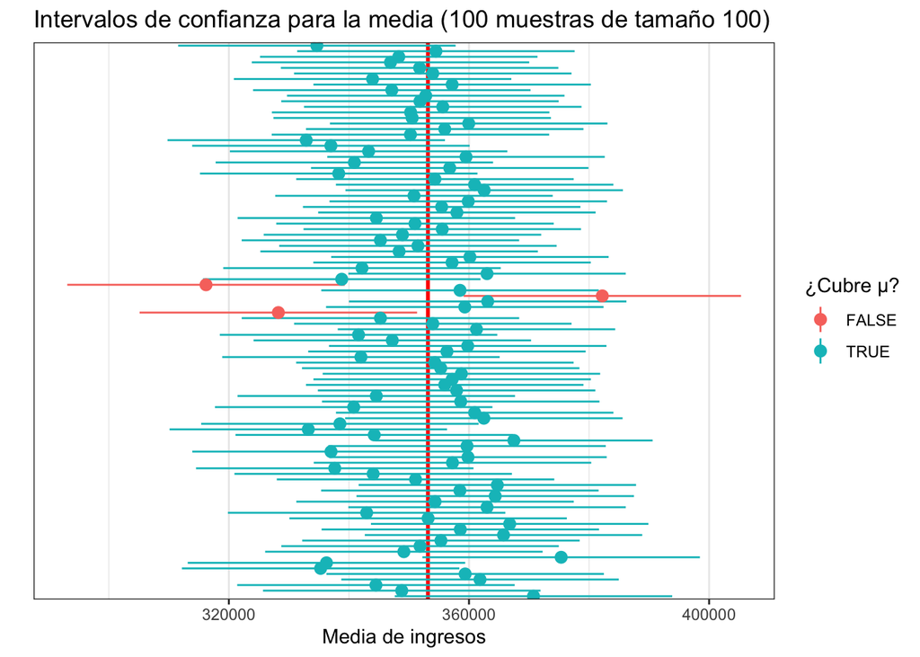

```r
#crea una variable para identificar cada muestra, utilizando el nro de fila
intervaloconfianza_ingresos$id <- rownames(intervaloconfianza_ingresos)

ggplot(intervaloconfianza_ingresos, aes(x = id, y = mediaingresos, ymin = limiteinferior, ymax = limitesuperior, group= indx, color = indx)) +
  geom_hline(yintercept  = mean(tarapaca$ingresos), colour = "red", size = 1) + #crea una linea horizontal que representa la media poblacional
  geom_pointrange(aes(ymin = limiteinferior, ymax = limitesuperior)) +
  theme_bw() +
  ggtitle("Intervalos de confianza para la media (100 muestras de tamaño 100)") +
  labs(colour="¿Cubre μ?", x = "", y ="Media de ingresos") +
  scale_x_discrete(breaks = "") +
  coord_flip()
```

Pero ¿qué pasa cuándo no conocemos el error estándar de una distribución muestral? Si vuelves a revisar el capítulo 7 de Ferris, sabrás que podemos estimarlo a partir de cualquier muestra, utilizando la desviación estándar de la muestra y la raíz cuadrada de su tamaño.